# Assignment 6

# 4. Use the codes in the slides to plot the stock of Apple. Also:

```r
library(quantmod)
getSymbols('AAPL', src='yahoo')
```

```
## [1] "AAPL"
```

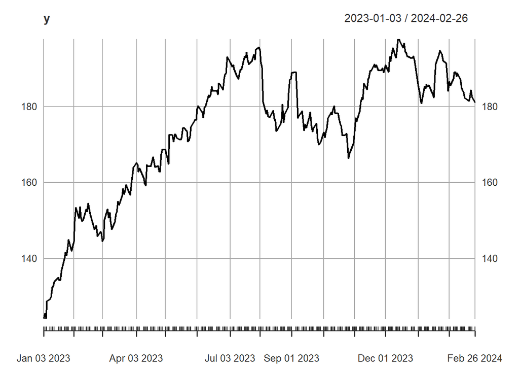

```r
y = Ad(AAPL[index(AAPL)>"2023-01-01",])
plot(y)
```

- Plot the differencing of the stock

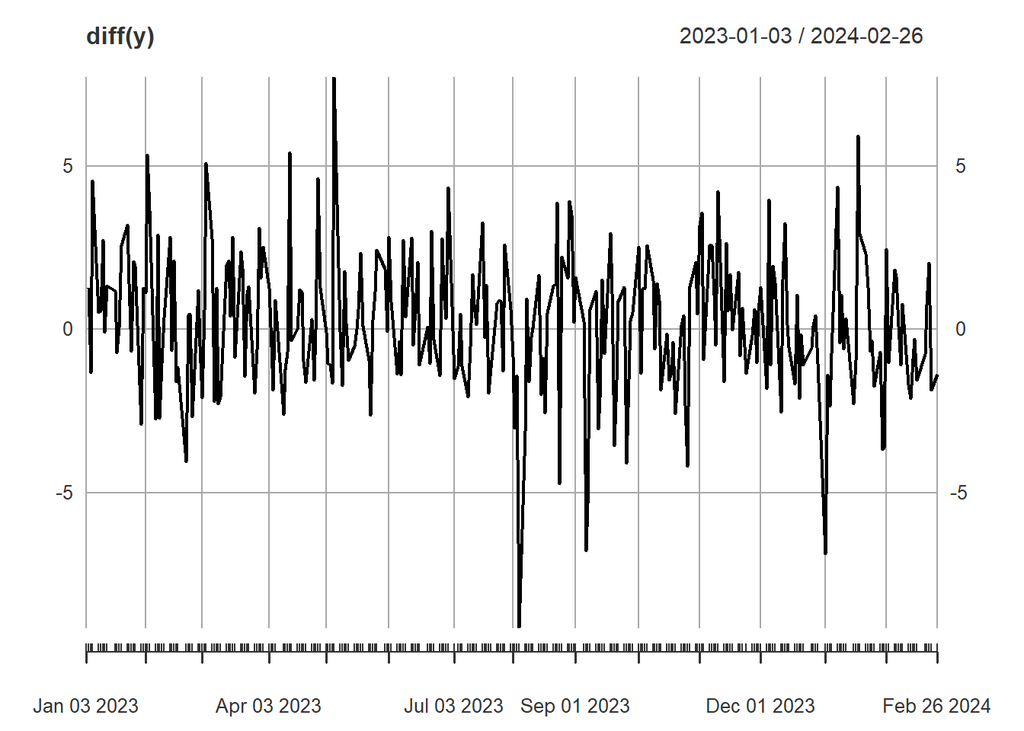

```r
plot(diff(y))
```

- Plot the ACF of the differencing of the stock

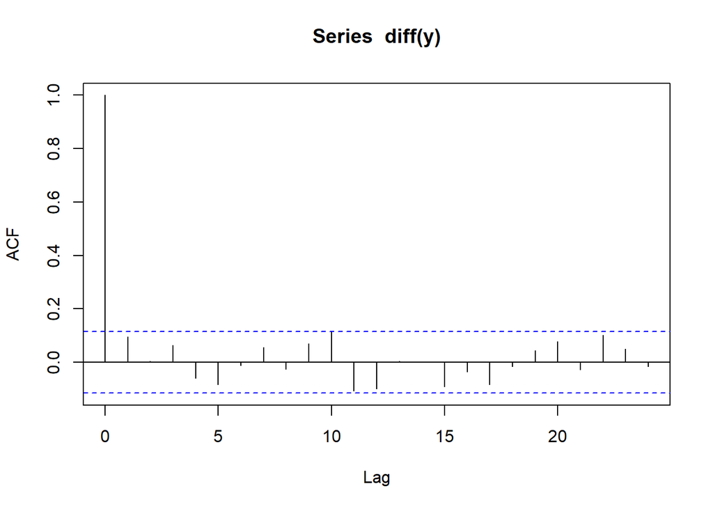

```r
acf(diff(y), na.action = na.pass)
```

# Is it reasonable to assume that Apple stock is following the random walk model?

- Yes, it is reasonable to assume that the stock follows the random walk model.
- It follows the same characteristics as the slides for the Microsoft stock example

# 5. Find other stocks that may be following the random walk model.

- Disney (DIS):

```r
library(quantmod)

#Disney stock
getSymbols('DIS', src='yahoo')
```

```
## [1] "DIS"
```

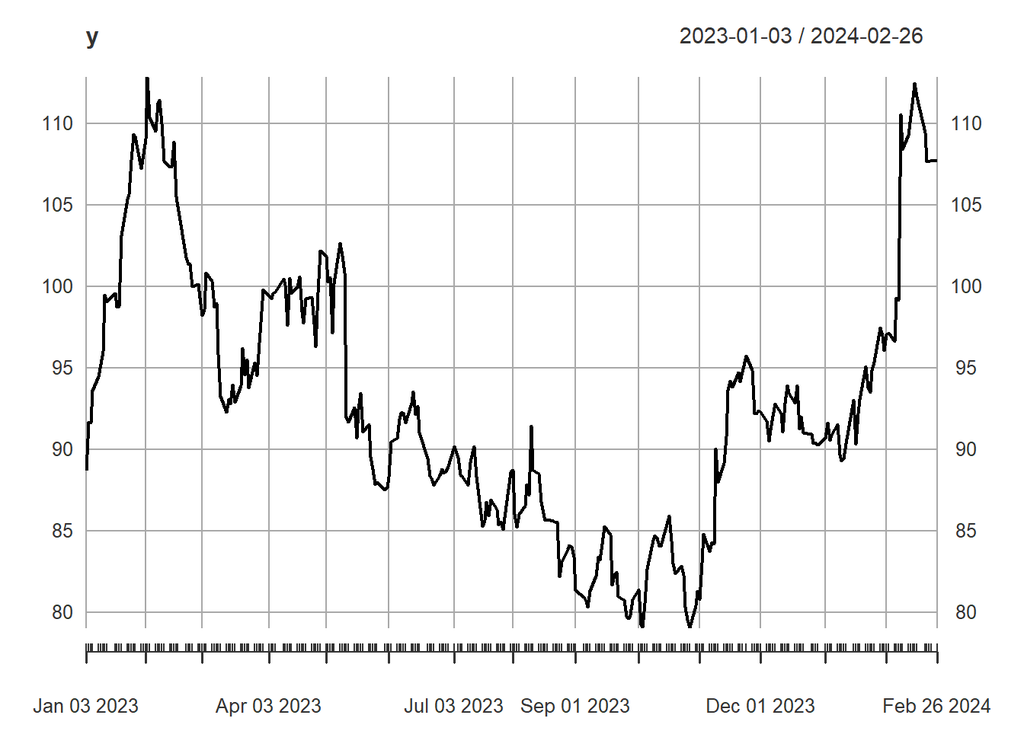

```r
y = Ad(DIS[index(DIS)>"2023-01-01",])
plot(y)
```

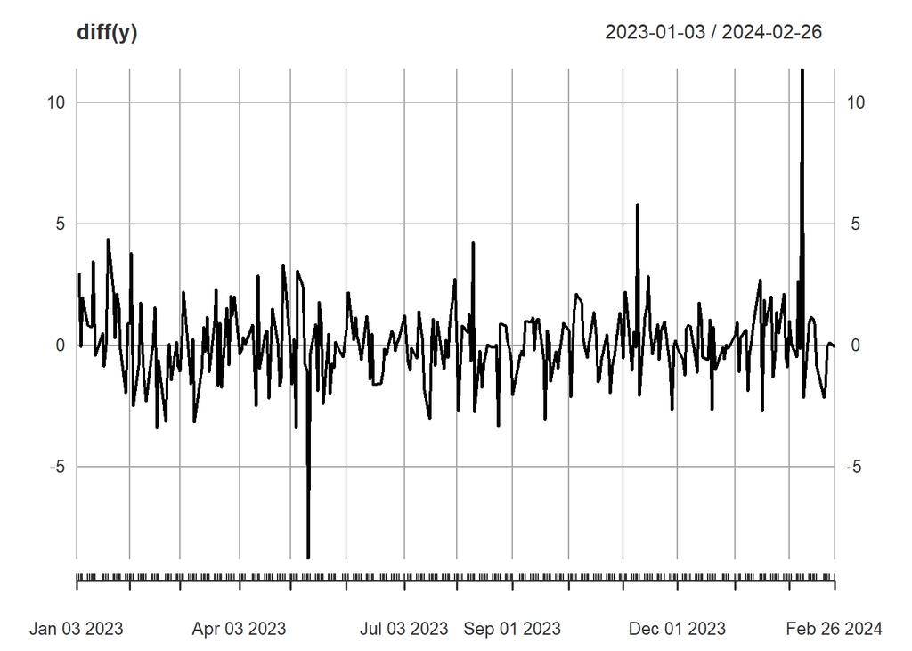

```r
#plot differencing
plot(diff(y))
```

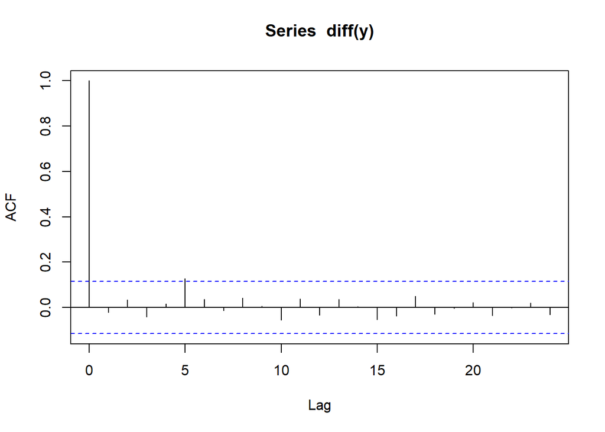

```r
#acf of differencing
acf(diff(y), na.action = na.pass)
```

- Amazon (AMZN):

```r
library(quantmod)

#Amazon stock
getSymbols('AMZN', src='yahoo')
```

```
## [1] "AMZN"
```

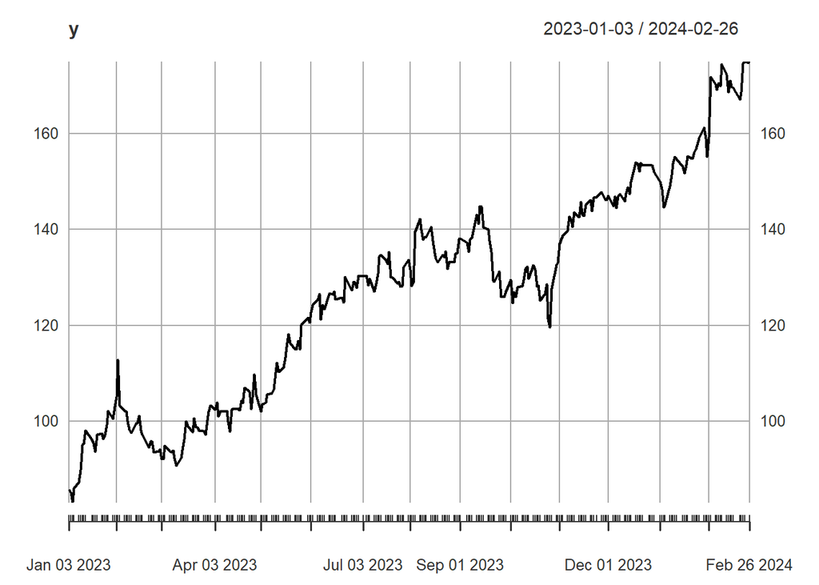

```r
y = Ad(AMZN[index(AMZN)>"2023-01-01",])
plot(y)
```

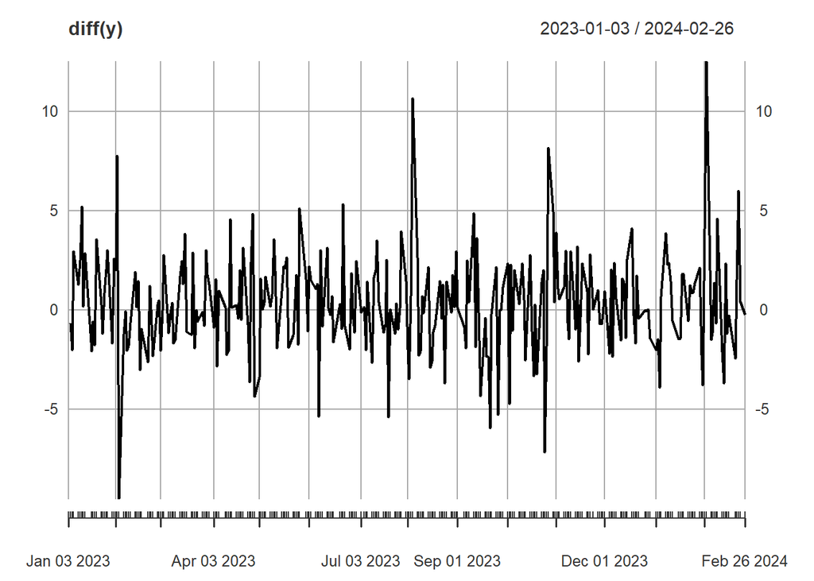

```r
#plot differencing
plot(diff(y))
```

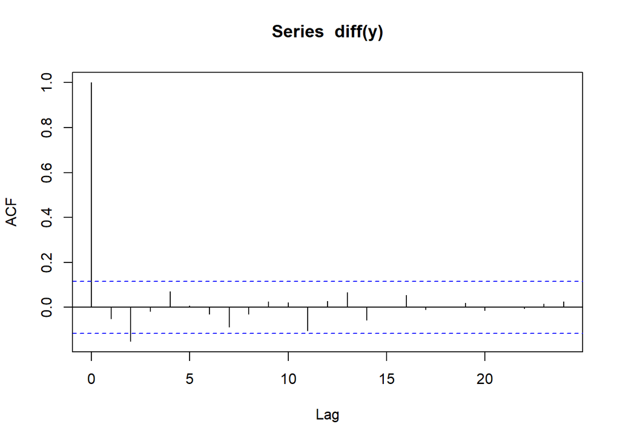

```r
#acf of differencing
acf(diff(y), na.action = na.pass)
```